# Introduction To dplyr in R for Data Manipulation

Andy Pickering

Jan 10, 2018

# Introduction

- This is an introduction to the dplyr package, as part of the Denver R Users Meetup on Jan 10, 2018
- It is geared towards those getting started R
- dplyr is a package for working with and manipulating data frames

# dplyr is tidy

- dplyr is part of the ‘tidyverse’, a set of packages designed to work with tidy data or help you make your data tidy
- A very basic definition of ‘tidy’ is : your data is in a table or dataframe where each column is a variable, and each row is a separate observation.

# The verbs!

### dplyr has 5 main verbs that each do 1 thing:

- select
- arrange
- filter
- mutate
- summarise

I’ll use the *mtcars* dataset for examples.

```r
suppressPackageStartupMessages(library(dplyr))
head(mtcars)
```

```
##                    mpg cyl disp  hp drat    wt  qsec vs am gear carb
## Mazda RX4         21.0   6  160 110 3.90 2.620 16.46  0  1    4    4
## Mazda RX4 Wag     21.0   6  160 110 3.90 2.875 17.02  0  1    4    4
## Datsun 710        22.8   4  108  93 3.85 2.320 18.61  1  1    4    1
## Hornet 4 Drive    21.4   6  258 110 3.08 3.215 19.44  1  0    3    1
## Hornet Sportabout 18.7   8  360 175 3.15 3.440 17.02  0  0    3    2
## Valiant           18.1   6  225 105 2.76 3.460 20.22  1  0    3    1
```

## select

- ‘select’ selects columns from a data frame.
- Same as SQL select

```r
# select specified columns
df <- select(mtcars,mpg,cyl)
head(df,5)
```

```
##                    mpg cyl
## Mazda RX4         21.0   6
## Mazda RX4 Wag     21.0   6
## Datsun 710        22.8   4
## Hornet 4 Drive    21.4   6
## Hornet Sportabout 18.7   8
```

#### With Base R

```r
head(mtcars[c('mpg','cyl')])
```

```
##                    mpg cyl
## Mazda RX4         21.0   6
## Mazda RX4 Wag     21.0   6
## Datsun 710        22.8   4
## Hornet 4 Drive    21.4   6
## Hornet Sportabout 18.7   8
## Valiant           18.1   6
```

```r
head(mtcars[1:2])
```

```
##                    mpg cyl
## Mazda RX4         21.0   6
## Mazda RX4 Wag     21.0   6
## Datsun 710        22.8   4
## Hornet 4 Drive    21.4   6
## Hornet Sportabout 18.7   8
## Valiant           18.1   6
```

```r
# select everything *but* a column
df <- select(mtcars,-cyl)
head(df,5)
```

```
##                    mpg disp  hp drat    wt  qsec vs am gear carb
## Mazda RX4         21.0  160 110 3.90 2.620 16.46  0  1    4    4
## Mazda RX4 Wag     21.0  160 110 3.90 2.875 17.02  0  1    4    4
## Datsun 710        22.8  108  93 3.85 2.320 18.61  1  1    4    1
## Hornet 4 Drive    21.4  258 110 3.08 3.215 19.44  1  0    3    1
## Hornet Sportabout 18.7  360 175 3.15 3.440 17.02  0  0    3    2
```

```r
# select columns starting with x...
df <- select(mtcars,starts_with('d'))
head(df,5)
```

```
##                   disp drat
## Mazda RX4          160 3.90
## Mazda RX4 Wag      160 3.90
## Datsun 710         108 3.85
## Hornet 4 Drive     258 3.08
## Hornet Sportabout  360 3.15
```

## arrange

- Sorts rows by one or more specified variables
- Similar to SQL *order by*

```r
df <- arrange(mtcars,mpg)
head(df)
```

```
##    mpg cyl disp  hp drat    wt  qsec vs am gear carb
## 1 10.4   8  472 205 2.93 5.250 17.98  0  0    3    4
## 2 10.4   8  460 215 3.00 5.424 17.82  0  0    3    4
## 3 13.3   8  350 245 3.73 3.840 15.41  0  0    3    4
## 4 14.3   8  360 245 3.21 3.570 15.84  0  0    3    4
## 5 14.7   8  440 230 3.23 5.345 17.42  0  0    3    4
## 6 15.0   8  301 335 3.54 3.570 14.60  0  1    5    8
```

## filter

- filters rows based on given critera
- SQL equivalent would be *where …*

```r
df <- filter(mtcars,mpg>30)
head(df)
```

```
##    mpg cyl disp  hp drat    wt  qsec vs am gear carb
## 1 32.4   4 78.7  66 4.08 2.200 19.47  1  1    4    1
## 2 30.4   4 75.7  52 4.93 1.615 18.52  1  1    4    2
## 3 33.9   4 71.1  65 4.22 1.835 19.90  1  1    4    1
## 4 30.4   4 95.1 113 3.77 1.513 16.90  1  1    5    2
```

#### With Base R

```r
subset(mtcars,mpg>30)
```

```
##                 mpg cyl disp  hp drat    wt  qsec vs am gear carb
## Fiat 128       32.4   4 78.7  66 4.08 2.200 19.47  1  1    4    1
## Honda Civic    30.4   4 75.7  52 4.93 1.615 18.52  1  1    4    2
## Toyota Corolla 33.9   4 71.1  65 4.22 1.835 19.90  1  1    4    1
## Lotus Europa   30.4   4 95.1 113 3.77 1.513 16.90  1  1    5    2
```

## mutate

- Create new columns (or alter existing columns)

```r
df <- mutate(mtcars,mpkm = mpg*1.60934)
df <- select(df,mpg,mpkm)
head(df)
```

```
##    mpg     mpkm
## 1 21.0 33.79614
## 2 21.0 33.79614
## 3 22.8 36.69295
## 4 21.4 34.43988
## 5 18.7 30.09466
## 6 18.1 29.12905
```

### With Base R

```r
mtcars$mpkm <- mtcars$mpg*1.60934
head(mtcars)
```

```
##                    mpg cyl disp  hp drat    wt  qsec vs am gear carb
## Mazda RX4         21.0   6  160 110 3.90 2.620 16.46  0  1    4    4
## Mazda RX4 Wag     21.0   6  160 110 3.90 2.875 17.02  0  1    4    4
## Datsun 710        22.8   4  108  93 3.85 2.320 18.61  1  1    4    1
## Hornet 4 Drive    21.4   6  258 110 3.08 3.215 19.44  1  0    3    1
## Hornet Sportabout 18.7   8  360 175 3.15 3.440 17.02  0  0    3    2
## Valiant           18.1   6  225 105 2.76 3.460 20.22  1  0    3    1
##                       mpkm
## Mazda RX4         33.79614
## Mazda RX4 Wag     33.79614
## Datsun 710        36.69295
## Hornet 4 Drive    34.43988
## Hornet Sportabout 30.09466
## Valiant           29.12905
```

## summarise()

- More commonly used with group-by (see below)

#### Compute an average

```r
df <- summarise(mtcars,avg_mpg=mean(mpg))
df
```

```
##    avg_mpg
## 1 20.09062
```

#### Count the number of distinct values

```r
df <- summarise(mtcars,N_distinct_gears=n_distinct(gear))
df
```

```
##   N_distinct_gears
## 1                3
```

# The pipe!

- I’ll be using the *pipe* operator in these examples. The pipe takes the object on the left side and inputs it as the 1st argument to the function on the right.
- This eliminates the need for intermediate objects and can make code easier to read.
- Let’s say we want to select only the mpg,cyl, and disp columns, then filter by cyl, then order by mpg.

## without pipe

```r
# without pipe
df <- select(mtcars,mpg,cyl,disp)
df <- filter(df,cyl==8)
df <- arrange(df,mpg)
head(df)
```

[output not shown]

## with pipe

```r
df <- mtcars %>% select(mpg,cyl,disp) %>% filter(cyl==8) %>% arrange(mpg)
head(df)
```

```
##    mpg cyl disp
## 1 10.4   8  472
## 2 10.4   8  460
## 3 13.3   8  350
## 4 14.3   8  360
## 5 14.7   8  440
## 6 15.0   8  301
```

You can also pipe your results directly into ggplot!

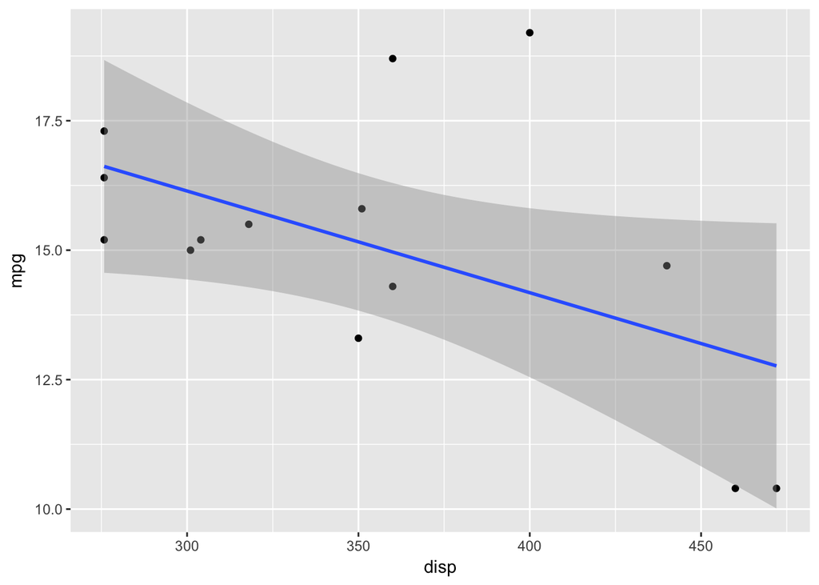

```r
library(ggplot2)
mtcars %>% select(mpg,cyl,disp) %>%
          filter(cyl==8) %>%
          arrange(mpg) %>%
          ggplot(aes(disp,mpg))+
          geom_point()+
          geom_smooth(method='lm')
```

## group by

- Group by 1 or more variables, and perform operations (ie average/sum) on each group

#### Example: Compute the average mpg for each number of cyl

```r
mtcars %>% group_by(cyl) %>% summarise(avg=mean(mpg))
```

```
## # A tibble: 3 x 2
##     cyl      avg
##   <dbl>    <dbl>
## 1     4 26.66364
## 2     6 19.74286
## 3     8 15.10000
```

## Joins

- dplyr also does all the joins: inner,left,right,semi,anti…

# Resources

http://dplyr.tidyverse.org/

https://www.datacamp.com/courses/dplyr-data-manipulation-r-tutorial

https://www.datacamp.com/courses/joining-data-in-r-with-dplyr